# Pertemuan 2 MPDW

Muhamad Farras Surya Dio Putra

2023-12-17

## Pemanggilan *Packages*

```r
library(forecast)
```

```r
library(graphics)
library(TTR)
library(TSA)
library(rio)
library(ggplot2)
library(lmtest)
library(orcutt)
library(HoRM)
library(corrplot)
library(RColorBrewer)
library(scales)
```

## Membaca Data

```r
dataset = import("https://raw.githubusercontent.com/farrasdp/mpdw/main/Pertemuan%202/data_wine.csv")
flip <- function(data){
  new <- data[rev(rownames(data)),]
  rownames(new) <- NULL
  new
}

dataset <- flip(dataset)
```

## Eksplorasi Data

```r
#Ekplorasi data
summary(dataset)
```

```
##      Tahun          Panen          Produksi          Harga
##  Min.   :1980   Min.   :  501   Min.   :  4307   Min.   :211.0
##  1st Qu.:1990   1st Qu.: 1374   1st Qu.:  9664   1st Qu.:362.0
##  Median :2000   Median : 8704   Median : 60739   Median :560.6
##  Mean   :2000   Mean   : 7646   Mean   : 53633   Mean   :536.6
##  3rd Qu.:2010   3rd Qu.:12002   3rd Qu.: 84853   3rd Qu.:692.7
##  Max.   :2020   Max.   :19200   Max.   :150000   Max.   :865.4
```

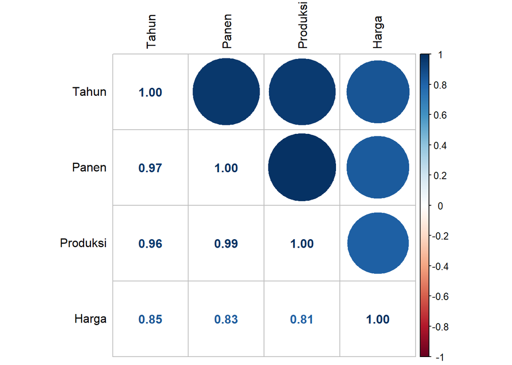

```r
# Membuat matriks korelasi
matrix <- cor(dataset)

corrplot.mixed(matrix, upper = 'circle', lower = 'number', order = "original",
               tl.col="black", tl.pos = "lt",diag = 'l',
               number.digits=2,number.cex=1)
```

Sebagai peubah respon: `Harga` Sebagai peubah penjelas: `Tahun`, `Panen`, `Produksi`

Pada matriks korelasi diatas menunjukan bahwa peubah Tahun, Panen, dan Produksi memiliki nilai korelasi yang tinggi terhadap peubah Harga. Oleh karena itu, peubah-peubah inilah yang akan digunakan sebagai peubah penjelas dalam tahapan analisis berikutnya.

### Plot Time Series

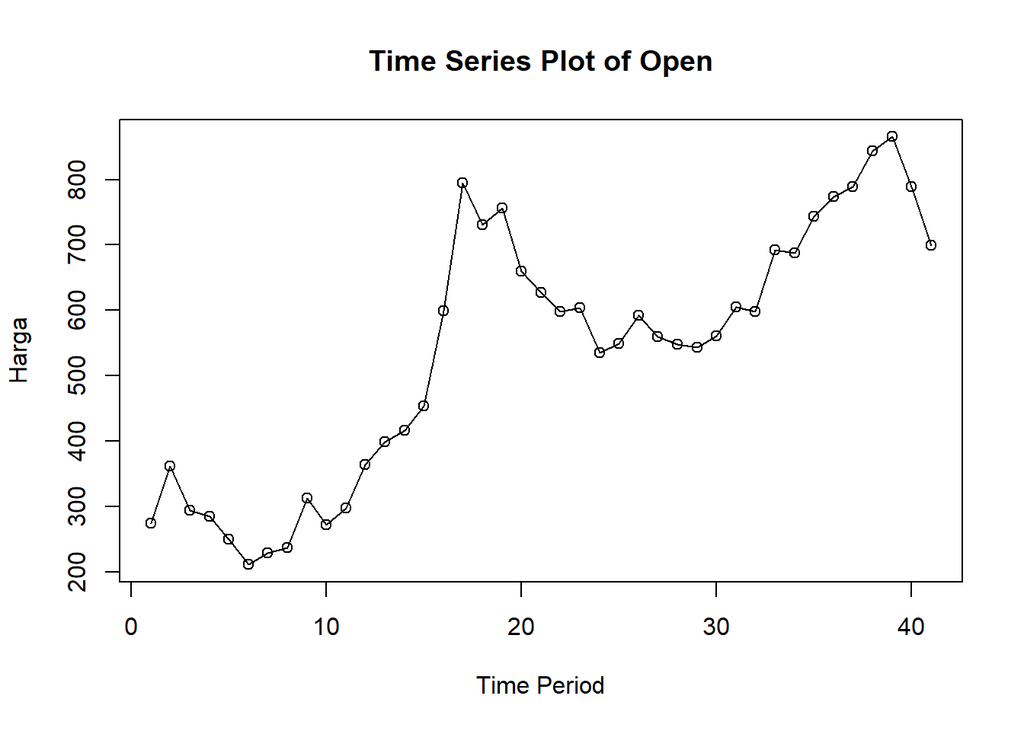

```r
#Membentuk objek time series
dataset.ts <- ts(dataset$Harga)

#Plot time series
ts.plot(dataset.ts, xlab = "Time Period",
        ylab = "Harga",
        main = "Time Series Plot of Open")
points(dataset.ts)
```

Ketika dibuat plot time series dari data diatas, dapat dilihat bahwa data tersebut berpola trend.

## Regresi

```r
#Pembuatan Model Regresi
#model regresi
model<- lm(Harga~Panen+Produksi, data = dataset)
summary(model)
```

```
##
## Call:
## lm(formula = Harga ~ Panen + Produksi, data = dataset)
##
## Residuals:
##     Min      1Q  Median      3Q     Max
## -146.80  -80.38  -28.22   62.81  311.13
##
## Coefficients:
##               Estimate Std. Error t value Pr(>|t|)
## (Intercept) 311.237570  29.007553  10.730 4.65e-13 ***
## Panen         0.054844   0.021327   2.572   0.0142 *
## Produksi     -0.003617   0.002932  -1.234   0.2249
## ---
## Signif. codes:  0 '***' 0.001 '**' 0.01 '*' 0.05 '.' 0.1 ' ' 1
##
## Residual standard error: 109 on 38 degrees of freedom
## Multiple R-squared:  0.7082, Adjusted R-squared:  0.6929
## F-statistic: 46.11 on 2 and 38 DF,  p-value: 6.861e-11
```

$$y_i =
311.237570+0.054844X1+-0.003617X2$$

Berdasarkan ringkasan model dapat diketahui bahwa hasil uji F memiliki 6.861e-11 < alpha (5%). Artinya, minimal terdapat satu variabel yang berpengaruh nyata terhadap model.

Selanjutnya dapat dilihat juga nilai $R^2=0.7082$. Artinya, sebesar 70,82% keragaman Harga dapat dijelaskan oleh peubah Panen dan Produksi. Hasil ini menunjukkan hasil yang bagus, seolah mendapatkan hasil terbaik. Namun, kita perlu melakukan uji terhadap sisaannya seperti berikut ini.

```r
#sisaan dan fitted value
sisaan<- residuals(model)
fitValue<- predict(model)
```

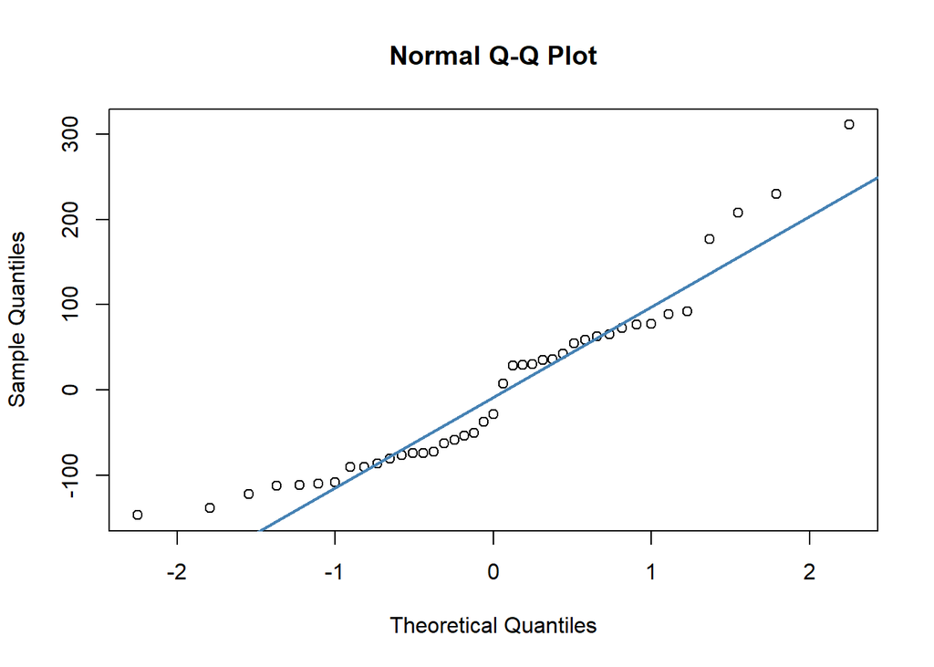

```r
#Diagnostik dengan eksploratif
par(mfrow = c(1,1))
qqnorm(sisaan)

#Normal Q-Q Plot
qqline(sisaan, col = "steelblue", lwd = 2)
```

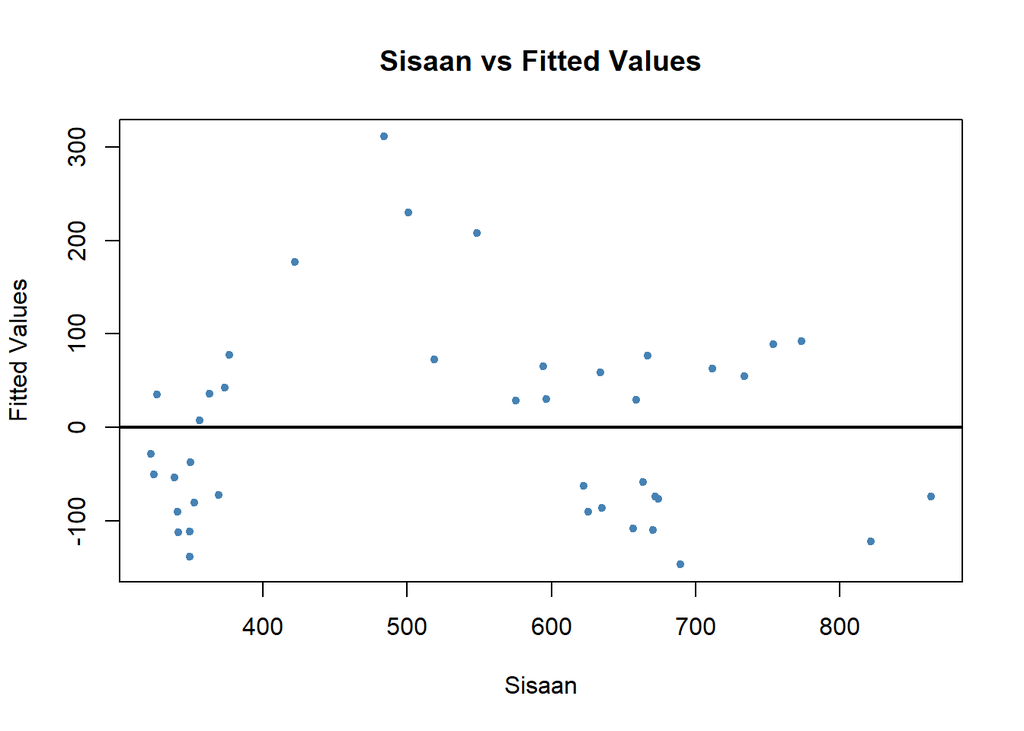

```r
plot(fitValue, sisaan, col = "steelblue", pch = 20, xlab = "Sisaan", ylab = "Fitted Values", main = "Sisaan vs Fitted Values")
abline(a = 0, b = 0, lwd = 2)
```

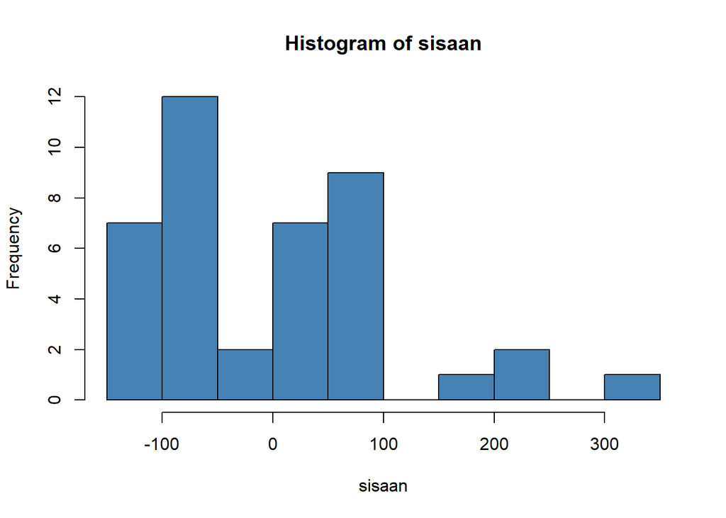

```r
#Histogram Sisaan
hist(sisaan, col = "steelblue")
```

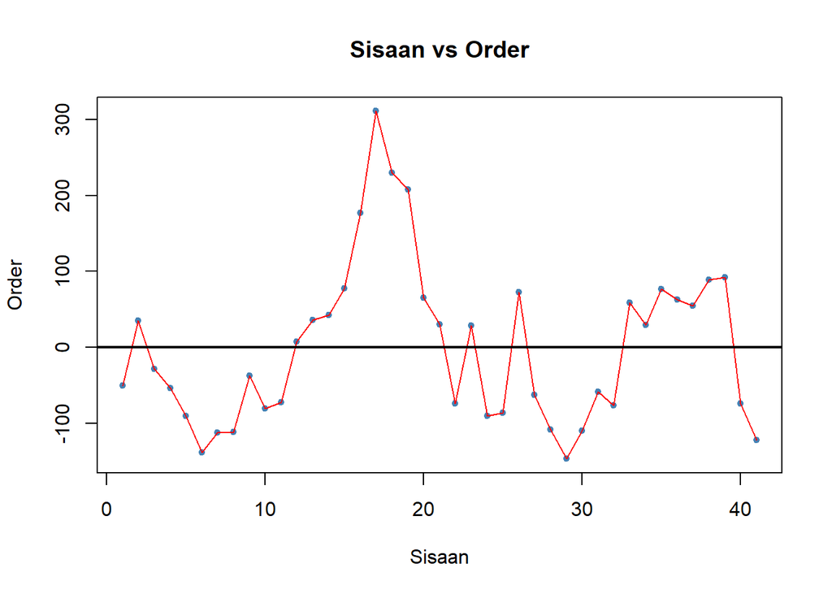

```r
plot(seq(1,41,1), sisaan, col = "steelblue", pch = 20, xlab = "Sisaan", ylab = "Order", main = "Sisaan vs Order")

lines(seq(1,41,1), sisaan, col = "red")
abline(a = 0, b = 0, lwd = 2)
```

1. Berdasarkan normal Q-Q Plot dan Histogram, terlihat bahwa sisaan cenderung menjulur ke kanan. 2. Berdasarkan plot Sisaan vs Fitted Values, terlihat bahwa sisaan cenderung menyebar tidak acak artinya sisaan tidak homogen. 3. Berdasarkan Plot sisaan vs Order, terlihat bahwa sisaan tidak menyebar acak atau terdapat pola naik turun. Hal tersebut mengindikasikan adanya autokorelasi.

## Uji Formal Normality Test

```r
#H0: sisaan mengikuti sebaran normal
#H1: sisaan tidak mengikuti sebaran normal
ks.test(sisaan, "pnorm", mean=mean(sisaan), sd=sd(sisaan))
```

```
##
##  Exact one-sample Kolmogorov-Smirnov test
##
## data:  sisaan
## D = 0.14611, p-value = 0.3143
## alternative hypothesis: two-sided
```

Berdasarkan tes normalitas menggunakan Kolmogorov-Smirnov Test didapatkan p-value > alpha (5%), artinya sisaan menyebar normal.

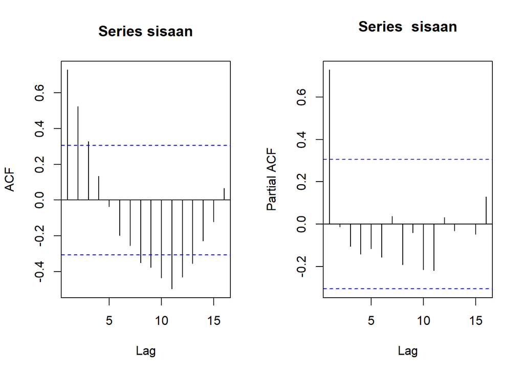

```r
#ACF dan PACF identifikasi autokorelasi
par(mfrow = c(1,2))
acf(sisaan)
pacf(sisaan)
```

Berdasarkan plot ACF dan PACF, terlihat bahwa bahwa garis melewati batas selang. Artinya, terjadi autokorelasi.

```r
#Deteksi autokorelasi dengan uji-Durbin Watson
#H0: tidak ada autokorelasi
#H1: ada autokorelasi
dwtest(model)
```

```
##
##  Durbin-Watson test
##
## data:  model
## DW = 0.50589, p-value = 6.815e-10
## alternative hypothesis: true autocorrelation is greater than 0
```

## Penanganan Autokorelasi

### Metode Cochrane-Orcutt

```r
#Penanganan Autokorelasi Cochrane-Orcutt
modelCO<-cochrane.orcutt(model)
modelCO
```

```
## Cochrane-orcutt estimation for first order autocorrelation
##
## Call:
## lm(formula = Harga ~ Panen + Produksi, data = dataset)
##
##  number of interaction: 66
##  rho 0.965278
##
## Durbin-Watson statistic
## (original):    0.50589 , p-value: 6.815e-10
## (transformed): 1.50646 , p-value: 6.45e-02
##
##  coefficients:
## (Intercept)       Panen    Produksi
## 1059.970775   -0.008448   -0.000292
```

Hasil keluaran model setelah dilakukan penanganan adalah sebagai berikut.
$$y_i=1059.970775+-0.008448x_1+-0.000292x_2$$
Hasil juga menunjukkan bahwa nilai DW dan p-value meningkat menjadi $1.50646$ dan $6.45e-02$. Hasil ini menunjukkan nilai DW belum berada dalam selang antara DU< DW< 4-DU sehingga masih ada autokorelasi, yaitu autokorelasi positif. Selanjutnya akan dilakukan transformasi secara manual dengan syntax berikut ini.

```r
#Rho optimum
rho<- modelCO$rho
rho
```

```
## [1] 0.9652782
```

```r
#Transformasi Manual
Harga.trans<- dataset$Harga[-1]-dataset$Harga[-41]*rho
Panen.trans<- dataset$Panen[-1]-dataset$Panen[-41]*rho
Produksi.trans<- dataset$Produksi[-1]-dataset$Produksi[-41]*rho
modelCOmanual<- lm(Harga.trans~Panen.trans+Produksi.trans)
summary(modelCOmanual)
```

```
##
## Call:
## lm(formula = Harga.trans ~ Panen.trans + Produksi.trans)
##
## Residuals:
##     Min      1Q  Median      3Q     Max
## -103.39  -31.93   -5.27   24.96  180.73
##
## Coefficients:
##                  Estimate Std. Error t value Pr(>|t|)
## (Intercept)    36.8040834 11.5142357   3.196  0.00285 **
## Panen.trans    -0.0084483  0.0128569  -0.657  0.51518
## Produksi.trans -0.0002921  0.0011100  -0.263  0.79388
## ---
## Signif. codes:  0 '***' 0.001 '**' 0.01 '*' 0.05 '.' 0.1 ' ' 1
##
## Residual standard error: 59.85 on 37 degrees of freedom
## Multiple R-squared:  0.03906,    Adjusted R-squared:  -0.01289
## F-statistic: 0.7519 on 2 and 37 DF,  p-value: 0.4785
```

```r
#Mencari Penduga Koefisien Regresi setelah Transformasi ke Persamaan Awal
b0bintang <- modelCOmanual$coefficients[-c(2,3)]
b0 <- b0bintang/(1-rho)
b1 <- modelCOmanual$coefficients[-c(1,3)]
b2 <- modelCOmanual$coefficients[-c(1,2)]
b0
```

```
## (Intercept)
##    1059.971
```

```r
b1
```

```
##  Panen.trans
## -0.008448279
```

```r
b2
```

```
## Produksi.trans
##  -0.0002921008
```

Penanganan autokorelasi menggunakan fungsi dan manual menunjukkan hasil yang sama.

### Metode Hildreth-Lu

Penanganan kedua adalah menggunakan metode Hildreth-Lu. Metode ini akan mencari nilai SSE terkecil dan dapat dicari secara manual maupun menggunakan packages.

```r
#Penanganan Autokorelasi Hildreth lu
# Hildreth-Lu
hildreth.lu.func<- function(r, model){
  x1 <- model.matrix(model)[,2]
  x2 <- model.matrix(model)[,3]

  y <- model.response(model.frame(model))
  n <- length(y)
  t <- 2:n

  y <- y[t]-r*y[t-1]
  x1 <- x1[t]-r*x1[t-1]
  x2 <- x2[t]-r*x2[t-1]

  return(lm(y~x1+x2))
}

#Pencariab rho yang meminimumkan SSE
r <- c(seq(0.1,0.9, by= 0.1))
tab <- data.frame("rho" = r, "SSE" = sapply(r, function(i){deviance(hildreth.lu.func(i, model))}))
round(tab, 4)
```

```
##   rho      SSE
## 1 0.1 386388.3
## 2 0.2 332217.9
## 3 0.3 285787.0
## 4 0.4 246968.7
## 5 0.5 215489.3
## 6 0.6 190742.1
## 7 0.7 171409.1
## 8 0.8 154865.9
## 9 0.9 138491.2
```

```r
#Rho optimal di sekitar 0.4
rOpt <- seq(0.9,1, by= 0.001)
tabOpt <- data.frame("rho" = rOpt, "SSE" = sapply(rOpt, function(i){deviance(hildreth.lu.func(i, model))}))
head(tabOpt[order(tabOpt$SSE),])
```

```
##      rho      SSE
## 66 0.965 132531.3
## 67 0.966 132532.2
## 65 0.964 132534.3
## 68 0.967 132537.0
## 64 0.963 132541.2
## 69 0.968 132545.8
```

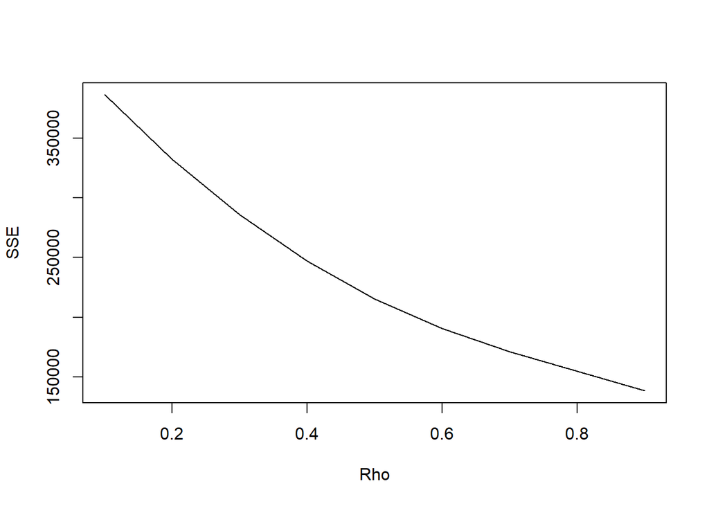

```r
#Grafik SSE optimum
par(mfrow = c(1,1))
plot(tab$SSE ~ tab$rho , type = "l", xlab = "Rho", ylab = "SSE")
abline(v = tabOpt[tabOpt$SSE==min(tabOpt$SSE),"rho"], lty = 2, col="red",lwd=2)
text(x=0.965, y=0.2397500, labels = "rho=0.965", cex = 0.8)
```

```r
#Model terbaik
modelHL <- hildreth.lu.func(0.965, model)
summary(modelHL)
```

```
##
## Call:
## lm(formula = y ~ x1 + x2)
##
## Residuals:
##      Min       1Q   Median       3Q      Max
## -103.324  -31.938   -5.263   25.024  180.751
##
## Coefficients:
##               Estimate Std. Error t value Pr(>|t|)
## (Intercept) 36.9534279 11.5234296   3.207  0.00277 **
## x1          -0.0084201  0.0128553  -0.655  0.51652
## x2          -0.0002921  0.0011101  -0.263  0.79390
## ---
## Signif. codes:  0 '***' 0.001 '**' 0.01 '*' 0.05 '.' 0.1 ' ' 1
##
## Residual standard error: 59.85 on 37 degrees of freedom
## Multiple R-squared:  0.0389, Adjusted R-squared:  -0.01305
## F-statistic: 0.7488 on 2 and 37 DF,  p-value: 0.48
```

```r
#Transformasi Balik
cat("y = ", coef(modelHL)[1]/(1-0.965), "+", coef(modelHL)[2],"x1","+", coef(modelHL)[3],"x2","+", sep = "")
```

```
## y = 1055.812+-0.008420103x1+-0.0002921234x2+
```

```r
#Deteksi autokorelasi
dwtest(modelHL)
```

```
##
##  Durbin-Watson test
##
## data:  modelHL
## DW = 1.5063, p-value = 0.06439
## alternative hypothesis: true autocorrelation is greater than 0
```

Hasil uji Durbin-Watson juga menunjukkan bahwa nilai DW sebesar $1.5063$ yang masih kurang dari nilai DU sehingga masih terdapat autokorelasi.

Terakhir, akan dibandingkan nilai SSE dari ketiga metode (metode awal, metode Cochrane-Orcutt, dan Hildreth-Lu)

```r
#Perbandingan
sseModelawal <- anova(model)$`Sum Sq`[-c(1,2)]
sseModelCO <- anova(modelCOmanual)$`Sum Sq`[-c(1,2)]
sseModelHL <- anova(modelHL)$`Sum Sq`[-c(1,2)]
mseModelawal <- sseModelawal/length(dataset$Harga)
mseModelCO <- sseModelCO/length(dataset$Harga)
mseModelHL <- sseModelHL/length(dataset$Harga)
akurasi <- matrix(c(sseModelawal,sseModelCO,sseModelHL,
                    mseModelawal,mseModelCO,mseModelHL),nrow=2,ncol=3,byrow = T)
colnames(akurasi) <- c("Model Awal", "Model Cochrane-Orcutt", "Model Hildreth-Lu")
row.names(akurasi) <- c("SSE","MSE")
akurasi
```

```
##     Model Awal Model Cochrane-Orcutt Model Hildreth-Lu
## SSE  451104.66            132531.161        132531.312
## MSE   11002.55              3232.467          3232.471
```

Berdasarkan hasil tersebut dapat diketahui bahwa hasil penanganan autokorelasi dengan metode Cochrane-Orcutt dan Hildreth-Lu memiliki SSE yang sama, sebesar $132531$ dan lebih baik dibandingkan model awal ketika autokorelasi masih terjadi, yaitu sebesar $451104.66$.

# Simpulan

Autokorelasi yang terdapat pada dataset wine di Yolo, california tahun 1980-2020 terjadi akibat adanya korelasi di antara unsur penyusunnya. Adanya autokorelasi menyebabkan model regresi kurang baik karena akan meingkatkan galatnya. Autokorelasi dapat dideteksi secara eksploratif melalui plot sisaan, ACF, dan PACF, serta dengan uji formal Durbin-Watson. Autokorelasi tersebut tidak dapat ditangani dengan metode Cochrane-Orcutt dan Hildreth-Lu. Kedua metode menghasilkan nilai SSE yang sama.